# GithHub Tutorial plsda Use case

How to proceed with our plsda (PLS1=one-Y-variable) algorithm, and function calls ?

The following use case as a tutorial expects to give main insights and some guidance. The code of functions can be fully deployed. Chosen data set : breast_cancer.

```r
setwd("C:/PLS1") # File directory
library(xlsx) # excel file in this use case
d <-read.xlsx(file="breast-cancer-pls-da.xlsx",sheetIndex=1,header=TRUE)
```

Qualitative target is the one to be explained and predicted. Summary : length : 699. 9 quantative variables[“X”] 1 qualitative [“Y target”] : “classe”.

```r
summary(d)
```

```
     clump          ucellsize        ucellshape       mgadhesion         sepics          bnuclei
 Min.   : 1.000   Min.   : 1.000   Min.   : 1.000   Min.   : 1.000   Min.   : 1.000   Min.   : 1.000
 1st Qu.: 2.000   1st Qu.: 1.000   1st Qu.: 1.000   1st Qu.: 1.000   1st Qu.: 2.000   1st Qu.: 1.000
 Median : 4.000   Median : 1.000   Median : 1.000   Median : 1.000   Median : 2.000   Median : 1.000
 Mean   : 4.418   Mean   : 3.134   Mean   : 3.207   Mean   : 2.807   Mean   : 3.216   Mean   : 3.555
 3rd Qu.: 6.000   3rd Qu.: 5.000   3rd Qu.: 5.000   3rd Qu.: 4.000   3rd Qu.: 4.000   3rd Qu.: 5.000
 Max.   :10.000   Max.   :10.000   Max.   :10.000   Max.   :10.000   Max.   :10.000   Max.   :10.000
   bchromatin        normnucl         mitoses          classe
 Min.   : 1.000   Min.   : 1.000   Min.   : 1.000   Length:699
 1st Qu.: 2.000   1st Qu.: 1.000   1st Qu.: 1.000   Class :character
 Median : 3.000   Median : 1.000   Median : 1.000   Mode  :character
 Mean   : 3.438   Mean   : 2.867   Mean   : 1.589
 3rd Qu.: 5.000   3rd Qu.: 4.000   3rd Qu.: 1.000
 Max.   :10.000   Max.   :10.000   Max.   :10.000
```

Extraction of the target variable and transformation into dummies. function to be called : “plsda.dummies” - encoding : S3 with print overload. Console output:print.dummies()

```r
plsda.dumnies <- function (X,name){

  instance <- list()
  # renvoyer la colonne spécifiée X en tant que facteur plutôt que numérique.
  instance$fX<- as.factor(as.vector(X))
  # les Modalités du facteur
  instance$levels <- levels(instance$fX)
  # Matrice d'indicatrices
  instance$dum <- sapply(instance$levels,function(x){ifelse(instance$fX==x,1,0)})
  class(instance) <- "dumnies"
  return(instance)
}

Y_dummy <- plsda.dumnies(d[,10])
#print(object)

#surcharger la méthode print pour afficher la matrice des variables indicatrices

print.dumnies <- function(objet){
  cat("dummy species ","\n")
  dumny <- as.matrix(objet$dum)
  print(head(dumny))

}
print.dumnies(Y_dummy)
```

```
dummy species
     begnin malignant
[1,]      1         0
[2,]      0         1
[3,]      0         1
[4,]      1         0
[5,]      1         0
[6,]      1         0
```

```r
plsda.scale <- function(X,reduce =TRUE){
  #vérifier si la matrice est numerique
  X<-as.matrix(X)
  if(typeof(X)!="double"){
    stop("Not expected character's matrix")
  }
  #creation of the instance that returns reduced centered matrix. Each variable-mean and its standard deviation are collected in a list
  instance <- list()
  #function mean applied row per row to each X column
  instance$mean <-apply(X,1,function(x){return(x-mean(x))})
  #condition on reduce
  if(reduce==TRUE){
  #compute the coefficients of the matrix in dividing the standard deviation

    instance$new_X <- apply(instance$mean,1,function(x){return(x/sd(x))})
    instance$new_mean_col <- apply(instance$new_X,2,mean)
    instance$new_mean_sd <- apply(instance$new_X,2,sd)
    class(instance) <- "scale"
    return(instance)
 }
}

#activation. Extraction of X
X<-as.matrix(data[1:9])
print(('Values before scaling : cf.print(head(X))'))
```

```
[1] "Values before scaling : cf.print(head(X))"
```

```r
print(head(X))
```

```
     clump ucellsize ucellshape mgadhesion sepics bnuclei bchromatin normnucl mitoses
[1,]     5         1          1          1      2       1          2        1       1
[2,]    10        10          7          8      7       1         10       10       3
[3,]     5         7         10         10      5      10         10       10       1
[4,]     5         2          2          2      3       1          1        3       1
[5,]     4         1          1          1      1       1          2        1       1
[6,]     3         1          1          1      2       1          2        1       2
```

```r
X_scale <-plsda.scale(X,reduce=TRUE)


#Overload of the print method

print.scale <- function(objet){
  cat("New column mean (should be around 0)",":")
  new_mean<-as.matrix(objet$new_mean_col)
  print(new_mean)
  cat("New column standard deviation (must be 1)",":")
  new_st<-as.matrix(objet$new_mean_sd)
  print(new_st)
  cat("New values after scaling processing ",":")
  new_x <- objet$new_X
  print(head(new_x))

}

#print(object)
print.scale(X_scale)
```

```
New column mean (should be around 0) :                  [,1]
clump       0.67833322
ucellsize  -0.00180506
ucellshape  0.05451563
mgadhesion -0.19667639
sepics      0.05651106
bnuclei     0.19325777
bchromatin  0.22188150
normnucl   -0.15164201
mitoses    -0.79877180
New column standard deviation (must be 1) :           [,1]
clump         1
ucellsize     1
ucellshape    1
mgadhesion    1
sepics        1
bnuclei       1
bchromatin    1
normnucl      1
mitoses       1
New values after scaling processing  :          clump  ucellsize ucellshape mgadhesion     sepics    bnuclei bchromatin   normnucl    mitoses
[1,]  1.7652826 -0.5046949 -0.5149517 -0.3973318  0.2379592 -0.3080665  0.2457927 -0.3745504 -0.3441242
[2,]  1.4122261  2.0187796 -0.2574758  0.3973318 -0.2379592 -2.9266321  1.9663413  1.4982016 -2.2368072
[3,] -1.3533834 -0.4205791  1.8881562  1.4568832 -1.8243540  1.1295773  1.8024795  1.3733515 -3.3838878
[4,]  1.4710689 -0.1682316 -0.1716506 -0.1324439  0.5552382 -0.5647887 -0.9012398  0.4369755 -0.6308943
[5,]  1.3533834 -0.3364633 -0.3433011 -0.2648879 -0.3172790 -0.2053777  0.4096544 -0.2497003 -0.2294161
[6,]  0.7649558 -0.4205791 -0.4291264 -0.3311098  0.3172790 -0.2567221  0.3277236 -0.3121253  0.2294161
```

Sample split into data_train/Test. Function to be called : “pls_split_sample” - encoding : S3 with print overload. Output function to call:print.split()

```r
#Class S3 split function
plsda.split_sample<-function(data,prop.train){

  # controle de prop.train
  if(prop.train>1 | prop.train<0){
    stop("Proportion non comprise entre 0 et 1")
  }
  #ok - on peut y aller
  n <- nrow(data)
  #make this example reproducible
  set.seed(1)
  # Selection des indices des individus de l'échantillon d'apprentisage
  index <- sample(1:n, size = n*prop.train ,replace = FALSE)
  #création de l'instance
  instance <- list()
  #echantillon d'apprentissage
  instance$train <- data[index,]
  #taille de l'échantillon d'apprentissage
  instance$train_size <- nrow( instance$train)
  #echantillon de test
  instance$test<- data[-index,]
  #taille de l'échantillon test
  instance$test_size <- nrow(instance$test)
  class(instance) <- "split"
  return(instance)

}
#example : split 0.60/0.40
train_test <- plsda.split_sample(d,prop.train=0.60)


#surcharge de la méthode print de manière à ce qu’elle affiche l'échantillon test et l'échantillon train
print.split <- function(objet){
  #Train sample display
  cat("train :")
  train <-  nrow(objet$train)
  print(train)

  #Test sample display
  cat("test:")
  test <- nrow(objet$test)
  print(test)

}
#activation
print.split(train_test)
```

```
train :[1] 419
test:[1] 280
```

```r
#verification
breast.train <-train_test$train
print(head(breast.train))
```

|  | clump | ucellsize | ucellshape | mgadhesion | sepics | bnuclei | bchromatin | normnucl | mitoses | classe |
| --- | --- | --- | --- | --- | --- | --- | --- | --- | --- | --- |
| 679 | 1 | 1 | 1 | 1 | 2 | 1 | 3 | 1 | 1 | begnin |
| 129 | 1 | 1 | 1 | 1 | 2 | 1 | 1 | 1 | 1 | begnin |
| 509 | 2 | 3 | 1 | 1 | 5 | 1 | 1 | 1 | 1 | begnin |
| 471 | 6 | 9 | 7 | 5 | 5 | 8 | 4 | 2 | 1 | begnin |
| 299 | 1 | 1 | 1 | 1 | 2 | 1 | 2 | 1 | 1 | begnin |
| 270 | 10 | 10 | 10 | 1 | 6 | 1 | 2 | 8 | 1 | malignant |

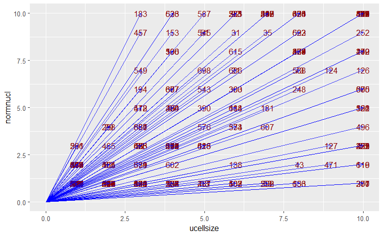

```r
library(ggplot2)
spread=ggplot() +
 geom_text(data=breast.train, aes(x = ucellsize, y = normnucl, label = rownames(breast.train)), col = 'darkred') +
 geom_segment(data=breast.train, aes(x = 0, y = 0, xend = ucellsize, yend = normnucl), arrow=arrow(length=unit(0.2,"cm")),alpha = 0.75, color = 'blue')
print(spread)
```

```r
 plsda.fit<-function(formula, data, ncomp = 2){

   #getting X et Y
  X <- model.matrix(formula, data = data)
  X <- X[,-1] #removal of the intercept
  Y <- model.response(model.frame(formula, data = data))
  Y <- as.factor(as.vector(Y))


  ## Check Y input
# Check if response variable is a factor (categorical variable)
check_Y<-function(Y){
  if (is.factor(Y)==FALSE){
    stop("The target variable must be a factor")
}
# Check if there is no missing values in target variable
  if (length(complete.cases(Y)[complete.cases(Y)])!= length(Y)){
    stop("No missing values allowed in target variable")
}
# Check if response variable contains at least 2 levels
  if(nlevels(Y)<2){
    stop("The response variable must contain at least 2 levels")
  }
}

  #Extraction of the target variable name
  Xname <- colnames(X)
  Yname <- intersect(all.vars(formula)[1],colnames(data))

  #calculation of Xmeans
  Xmeans <- colMeans(X)

  #definition of n (nb of observations), p (nb of explanatory variables), q (nb of modalities)
  n <- nrow(X)
  p <- ncol(X)
  q <- nlevels(Y)

   #getting the Y modality matrix
  Yb <- dummy_cols(Y) #can be proceeded with fastDummies package or with our Y_dummy S3+ function
  Yb <- Yb[,-1]
  colnames(Yb) <- levels(Y)

  #scaling X and Y
  Xk <- scale(X)
  Yk <- as.numeric(as.vector(Yb))


  #instanciation des matrics weight, scores et loading de X et Y
  Xweights <- matrix(0, p, ncomp)
  Yweights <- matrix(0, q, ncomp)
  Xscores <- matrix(0, n, ncomp)
  Yscores <- matrix(0, n, ncomp)
  Xloadings <- matrix(0, p, ncomp) #positioning of the explanatory variables on the factorial plan
  Yloadings <- matrix(0, q, ncomp) #positioning of the modalities

  u <- Yb[,1]

  #boucle for afin de remplir les matrices précédentes
  for (i in 1:ncomp){
    Wold <- rep(1,p)
    n_iter <- 1
    repeat{
      W <- t(Xk)%*%u/sum(u^2)
      W <- W/sqrt(sum(W^2))
      t <- Xk%*%W
      q <- t(Yk)%*%t/sum(t^2)
      u <- Yk%*%q/sum(q^2)
      Wdiff <- W-Wold
      if(sum(Wdiff^2) < 1e-10 | n_iter == 500){break}
      Wold <- W
      n_iter <- n_iter+1
    }
    t <- Xk%*%W
    u <- Yk%*%q/sum(q^2)
    Xl <- t(Xk)%*%t/sum(t^2)
    Xk <- Xk-t%*%t(Xl)
    Yl <- t(Yk)%*%t/sum(t^2)
    Yk <- Yk-t%*%t(Yl)

    Xweights[, i] <- W #Weights of X
    Yweights[, i] <- q #Weights of Y
    Xscores[, i] <- t
    Yscores[, i] <- u
    Xloadings[, i] <- Xl
    Yloadings[, i] <- Yl
  }

  Xrotations <- Xweights%*%solve(t(Xloadings)%*%Xweights)
  coef <- Xrotations%*%t(Yloadings)
  coef <- coef*sapply(Yb, sd)
  intercept <- colMeans(Yb)
  intercept <- colMeans(Yb)

  #Tables names
  compnames <- paste0("Comp.", 1:ncomp)

  rownames(Xweights) <- Xname
  colnames(Xweights) <- compnames
  rownames(Yweights) <- colnames(Yb)
  colnames(Yweights) <- compnames
  rownames(Xscores) <- rownames(X)
  colnames(Xscores) <- compnames
  rownames(Yscores) <- rownames(Yb)
  colnames(Yscores) <- compnames
  rownames(Xloadings) <- Xname
  colnames(Xloadings) <- compnames
  rownames(Yloadings) <- colnames (Yb)
  colnames(Yloadings) <- compnames
  rownames(coef) <- Xname
  colnames(coef) <- colnames(Yb)

  # Object definition
  objet <- list(
    "X" = X,
    "Y" = Yb,
    "Xname" = Xname,
    "Yname" = Yname,
    "modalities" = levels(Y),
    "Xmeans" = Xmeans,
    "Xweights" = Xweights,
    "Yweigths" = Yweights,
    "Xscores" = Xscores,
    "Yscores" = Yscores,
    "Xloadings" = Xloadings,
    "Yloadings" = Yloadings,
    "coef" = coef,
    "intercept" = intercept,
    "ncomp" = ncomp,
    "n_iter" = n_iter
  )
  class(objet)<-"PLSDA"
  return(objet)
}
#Classification function
print.classi <- function(objetPLSDA){
  classification <- rbind(objetPLSDA$coef, objetPLSDA$intercept)
  #rownames(classification[1:p,]) <- objetPLSDA$Xname

  cat("classification","\n")
  print(classification)
}


#Example:activation with ncomp=2


fit1<-plsda.fit(classe~.,breast.train,ncomp=2)
print(fit1)
```

[output not shown]

some examples to select only a given attribute:

```r
class
```

```r
print(fit1$intercept)
```

[output not shown]

```r
print(fit1$Xloadings)
```

[output not shown]

```r
print(fit1$Yloadings)
```

[output not shown]

Now, let’s proceed to the predict

```r
plsda.predict <- function(objetPLSDA, newdata, type = "class"){
  if (class(objetPLSDA) != "PLSDA") {
    stop("Objet_PLSDA must be a PLSDA class Object")
  }

  X <- apply(newdata, 1, function(x) x - colMeans(objetPLSDA$X))
  X <- X/apply(objetPLSDA$X,2, sd)

  Ypred <- t(X) %*% objetPLSDA$coef
  Ypred <- Ypred + colMeans(objetPLSDA$Y)


  Yexp <- apply(Ypred,1, exp)
  Ysoftmax <- t(Yexp/colSums(Yexp)) #softmax calculs

  if (type == "posterior"){
    objet1 <- list(
      "Ysoftmax"=Ysoftmax,
      "Ypred"=Ypred
    )
    return(objet1)
  }
  else if (type == "class"){
    pred <- apply(Ysoftmax,1,which.max) # prob max per line
    classYpred <- objetPLSDA$modalities[pred] # name of the class
    objet2 <- list(
      "predclass"=as.factor(classYpred),
      "Ypred"=Ypred
    )

    return(objet2)
  }
}
#Function activation
#pls <- plsda.fit(Species~., data = iris, ncomp = 2)
#plsda.predict(pls, newdata = iris[,1:4], type = "class")
```

[output not shown]